# Project 1

Igor Donchev

I am trying to grab data from the rental site and clean it up a bit so we can use it later.

```r
library(tidyverse)
library(rvest)
library(janitor)
```

# Scraping the site and fixing things

## Part 1a: Getting the stuff from the web page

So here I just put the website link and use rvest to get all the listing boxes from the page and stick them into a table.

```r
url <- "https://epfl-exts.github.io/rental-scrape/"

page <- read_html(url)
cards <- html_nodes(page, ".col-sm")

rental_raw <- tibble(
  object_type     = html_text(html_node(cards, ".object-type"), trim = TRUE),
  rooms           = html_text(html_node(cards, ".rooms"), trim = TRUE),
  price           = html_text(html_node(cards, ".price"), trim = TRUE),
  address         = html_text(html_node(cards, ".address"), trim = TRUE),
  living_space    = html_text(html_node(cards, ".living-space"), trim = TRUE),
  floor           = html_text(html_node(cards, ".floor"), trim = TRUE),
  usable_surface  = html_text(html_node(cards, ".usable-surface"), trim = TRUE),
  availability    = html_text(html_node(cards, ".availability"), trim = TRUE),
  card_button     = html_text(html_node(cards, ".card-button"), trim = TRUE)
)
```

Let’s see how big this table is.

```r
dim(rental_raw)
```

```
## [1] 612   9
```

## Part 1b: Fixing the numbers and names

The numbers are all mixed up with text right now like “CHF” or “m2”, so I’m using `parse_number()` to turn them into real numbers. Also fixing the column names and checking if the address says on request.

```r
rental_clean <- rental_raw %>%
  clean_names() %>%
  mutate(
    price_chf       = parse_number(price),
    living_space_m2 = parse_number(living_space),
    floor_num       = parse_number(floor),
    rooms_num       = parse_number(rooms),
    postcode_cat    = str_extract(address, "\\b\\d{4}\\b"),
    address_status  = if_else(
      str_detect(str_to_lower(address), "on request|sur demande"),
      "On Request",
      "Available"
    ),
    price_per_m2    = price_chf / living_space_m2
  )
```

Let’s look at what the dataset looks like now.

```r
glimpse(rental_clean)
```

```
## Rows: 612
## Columns: 16
## $ object_type     <chr> "Apartment", "Apartment", "Apartment", "Single house",…
## $ rooms           <chr> "3 Rooms", "4 Rooms", "4 Rooms", "6 Rooms", "4 Rooms",…
## $ price           <chr> "1900 CHF", "4500 CHF", "2100 CHF", "5500 CHF", "2340 …
## $ address         <chr> "Rue de la Terrassière 58, 1207 Genève", "Address on r…
## $ living_space    <chr> "Living space: 63 m2", "Living space: 185 m2", "Living…
## $ floor           <chr> "Floor: 4", "Floor: NA", "Floor: 50", "Floor: 3", "Flo…
## $ usable_surface  <chr> "Usable surface: NA", "Usable surface: NA", "Usable su…
## $ availability    <chr> "Availability: 01 Oct 2018\nSee More", "Availability: …
## $ card_button     <chr> "See More", "See More", "See More", "See More", "See M…
## $ price_chf       <dbl> 1900, 4500, 2100, 5500, 2340, 2895, 1980, NA, 3080, 20…
## $ living_space_m2 <dbl> 63, 185, NA, 170, 73, NA, 73, 150, 117, 75, 104, NA, 9…
## $ floor_num       <dbl> 4, NA, 50, 3, 1, 2, 11, 6, 5, 2, 6, 8, NA, NA, NA, 3, …
## $ rooms_num       <dbl> 3.0, 4.0, 4.0, 6.0, 4.0, 4.5, 4.0, 5.0, 4.0, 4.0, 5.0,…
## $ postcode_cat    <chr> "1207", "1290", "1202", "1248", "1219", "1204", "1217"…
## $ address_status  <chr> "Available", "On Request", "Available", "On Request", …
## $ price_per_m2    <dbl> 30.15873, 24.32432, NA, 32.35294, 32.05479, NA, 27.123…
```

And quick summary of prices and space just to see what we have.

```r
summary(rental_clean$price_chf)
```

```
##    Min. 1st Qu.  Median    Mean 3rd Qu.    Max.     NAs
##      30    2180    3500    4039    5250   22800      15
```

```r
summary(rental_clean$living_space_m2)
```

```
##    Min. 1st Qu.  Median    Mean 3rd Qu.    Max.     NAs
##     1.0    70.0   111.0   127.1   170.0   530.0      93
```

## Part 1b: Exploring the data and fixing types

Now I’m checking what data types R gave us for each column and making sure everything is converted properly. I am creating new numeric columns for calculations so we don’t lose any of the original scraped information.

```r
glimpse(rental_raw)
```

```
## Rows: 612
## Columns: 9
## $ object_type    <chr> "Apartment", "Apartment", "Apartment", "Single house", …
## $ rooms          <chr> "3 Rooms", "4 Rooms", "4 Rooms", "6 Rooms", "4 Rooms", …
## $ price          <chr> "1900 CHF", "4500 CHF", "2100 CHF", "5500 CHF", "2340 C…
## $ address        <chr> "Rue de la Terrassière 58, 1207 Genève", "Address on re…
## $ living_space   <chr> "Living space: 63 m2", "Living space: 185 m2", "Living …
## $ floor          <chr> "Floor: 4", "Floor: NA", "Floor: 50", "Floor: 3", "Floo…
## $ usable_surface <chr> "Usable surface: NA", "Usable surface: NA", "Usable sur…
## $ availability   <chr> "Availability: 01 Oct 2018\nSee More", "Availability: 0…
## $ card_button    <chr> "See More", "See More", "See More", "See More", "See Mo…
```

The columns all came in as character strings because they have text like “CHF” or “m2” mixed in. I will extract the numbers out into new numeric columns using `parse_number()` while keeping the original columns intact.

```r
rental_clean <- rental_raw %>%
  clean_names() %>%
  mutate(
    price_chf       = parse_number(price),
    living_space_m2 = parse_number(living_space),
    floor_num       = parse_number(floor),
    rooms_num       = parse_number(rooms),

    postcode_cat    = str_extract(address, "\\b\\d{4}\\b"),
      address_status  = if_else(
      str_detect(str_to_lower(address), "on request|sur demande"),
      "On Request",
      "Available"
    ),

      price_per_m2    = price_chf / living_space_m2
  )
```

### Adjustments made:

- Kept all 9 original raw character columns intact so no info is lost.
- Converted `price` to numeric `price_chf`.
- Converted `living_space` to numeric `living_space_m2`.
- Converted `floor` to numeric `floor_num`.
- Converted `rooms` to numeric `rooms_num`.
- Created `postcode_cat` by extracting the zip codes from the `address` text.
- Added `address_status` to tag hidden addresses (“On Request” vs “Available”).
- Calculated `price_per_m2` for cost analysis.

### Checking unique values for character columns

Let’s look at all distinct entries in the original text columns to spot any strange values or missing patterns.

```r
# Checking unique categories in object_type and availability
unique(rental_clean$object_type)
```

```
##  [1] "Apartment"          "Single house"       "Roof flat"
##  [4] "Loft"               "Row house"          "Duplex"
##  [7] "Studio"             "Attic flat"         "Villa"
## [10] "Bifamiliar house"   "Farm house"         "Terrace flat"
## [13] "Hobby room"         "Cellar compartment"
```

```r
unique(rental_clean$availability)
```

```
##  [1] "Availability: 01 Oct 2018\nSee More" "Availability: 01 Aug 2018\nSee More"
##  [3] "Availability: NA\nSee More"          "Availability: Immediately\nSee More"
##  [5] "Availability: 01 Sep 2018\nSee More" "Availability: 16 Sep 2018\nSee More"
##  [7] "Availability: 16 Jul 2018\nSee More" "Availability: 15 Aug 2018\nSee More"
##  [9] "Availability: 01 Nov 2018\nSee More" "Availability: 16 Aug 2018\nSee More"
## [11] "Availability: 15 Oct 2018\nSee More" "Availability: 14 Aug 2018\nSee More"
## [13] "Availability: 15 Sep 2018\nSee More" "Availability: 15 Jul 2018\nSee More"
## [15] "Availability: 15 Jan 2019\nSee More" "Availability: 22 Jul 2018\nSee More"
## [17] "Availability: 16 Nov 2018\nSee More" "Availability: 25 Jul 2018\nSee More"
## [19] "Availability: 31 Jul 2018\nSee More" "Availability: 01 Jan 2019\nSee More"
## [21] "Availability: 01 Dec 2018\nSee More"
```

```r
unique(rental_clean$address_status)
```

```
## [1] "Available"  "On Request"
```

### Checking ranges for numerical variables

```r
rental_clean %>%
  select(price_chf, living_space_m2, floor_num, rooms_num, price_per_m2) %>%
  summary()
```

```
##    price_chf     living_space_m2   floor_num        rooms_num
##  Min.   :   30   Min.   :  1.0   Min.   : 1.000   Min.   : 1.000
##  1st Qu.: 2180   1st Qu.: 70.0   1st Qu.: 2.000   1st Qu.: 3.500
##  Median : 3500   Median :111.0   Median : 3.000   Median : 5.000
##  Mean   : 4039   Mean   :127.1   Mean   : 3.741   Mean   : 4.866
##  3rd Qu.: 5250   3rd Qu.:170.0   3rd Qu.: 5.000   3rd Qu.: 6.000
##  Max.   :22800   Max.   :530.0   Max.   :50.000   Max.   :13.000
##  NAs    :15      NAs    :93      NAs    :222      NAs    :24
##   price_per_m2
##  Min.   :   8.302
##  1st Qu.:  28.013
##  Median :  33.194
##  Mean   :  38.531
##  3rd Qu.:  38.180
##  Max.   :2180.000
##  NAs    :106
```

# Visualizing the data

## Part 2: Plotting price vs. living space

I am creating a scatterplot here using `ggplot2` to see if bigger apartments cost more money.

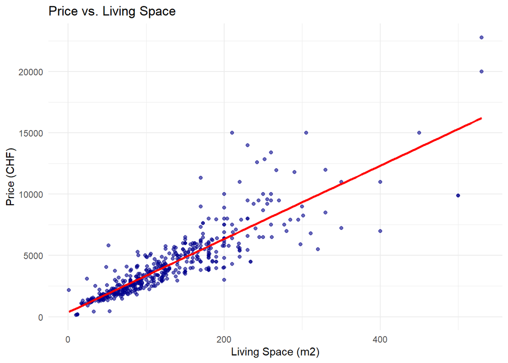

```r
library(ggplot2)

ggplot(rental_clean, aes(x = living_space_m2, y = price_chf)) +
  geom_point(alpha = 0.6, color = "darkblue") +
  geom_smooth(method = "lm", se = FALSE, color = "red") +
  labs(
    title = "Price vs. Living Space",
    x = "Living Space (m2)",
    y = "Price (CHF)"
  ) +
  theme_minimal()
```

Looking at the plot, there is a upward trend—as living space increases, the price generally goes up as well.

The red trend line confirms that bigger places generally cost more money on average.

## Part 3: Counting properties by postcode

Here I am creating a bar plot using `ggplot2` to count how many rental listings are located in each postcode area. This will help us see if the agency is more active in certain neighborhoods than others.

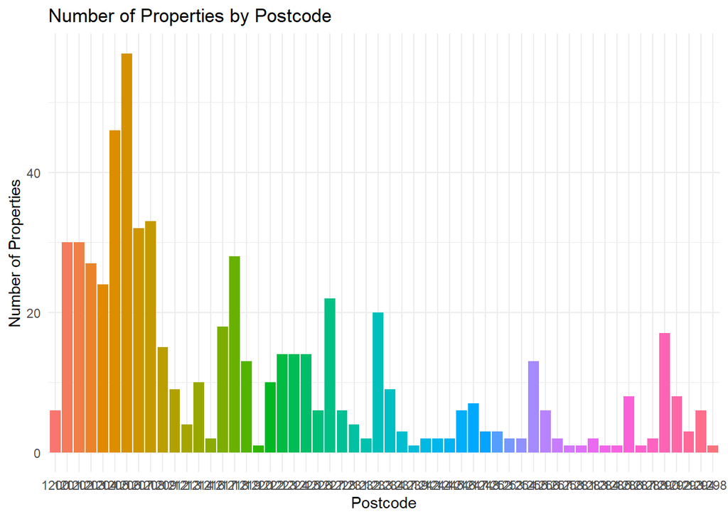

```r
library(ggplot2)

ggplot(rental_clean, aes(x = postcode_cat, fill = postcode_cat)) +
  geom_bar() +
  labs(
    title = "Number of Properties by Postcode",
    x = "Postcode",
    y = "Number of Properties",
    fill = "Postcode"
  ) +
  theme_minimal() +
  theme(legend.position = "none")
```

## Part 4: Price vs. Living Space by Floor (facets) and Postcode (colors)

Here I am creating 6 scatterplots separated by floor level using `facet_wrap()`, while using colors to show the different postcode areas in each plot.

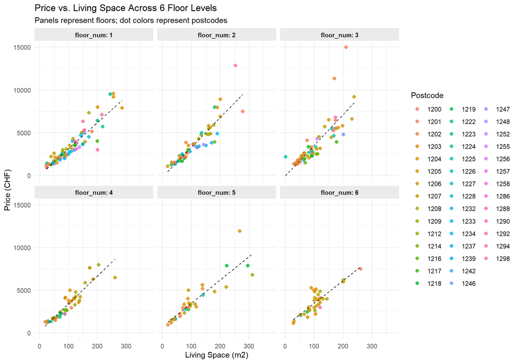

```r
library(ggplot2)
library(dplyr)


rental_floors <- rental_clean %>%
  filter(!is.na(floor_num) & floor_num %in% 1:6) %>%
  filter(!is.na(postcode_cat))

ggplot(rental_floors, aes(x = living_space_m2, y = price_chf, color = postcode_cat)) +
  geom_point(alpha = 0.8, size = 2) +
  geom_smooth(method = "lm", se = FALSE, color = "black", linetype = "dashed", size = 0.5) +
  facet_wrap(~ floor_num, ncol = 3, labeller = label_both) +
  labs(
    title = "Price vs. Living Space Across 6 Floor Levels",
    subtitle = "Panels represent floors; dot colors represent postcodes",
    x = "Living Space (m2)",
    y = "Price (CHF)",
    color = "Postcode"
  ) +
  theme_minimal() +
  theme(
    strip.background = element_rect(fill = "grey92", color = NA),
    strip.text = element_text(face = "bold")
  )
```

## Part 5: Comparing “On Request” listings vs. “Available” listings

Here I am analyzing whether properties with hidden addresses (“On Request” or “Sur Demande”) differ systematically from properties with publicly listed addresses in terms of **price** and **living space**.

### 1. Price Comparison

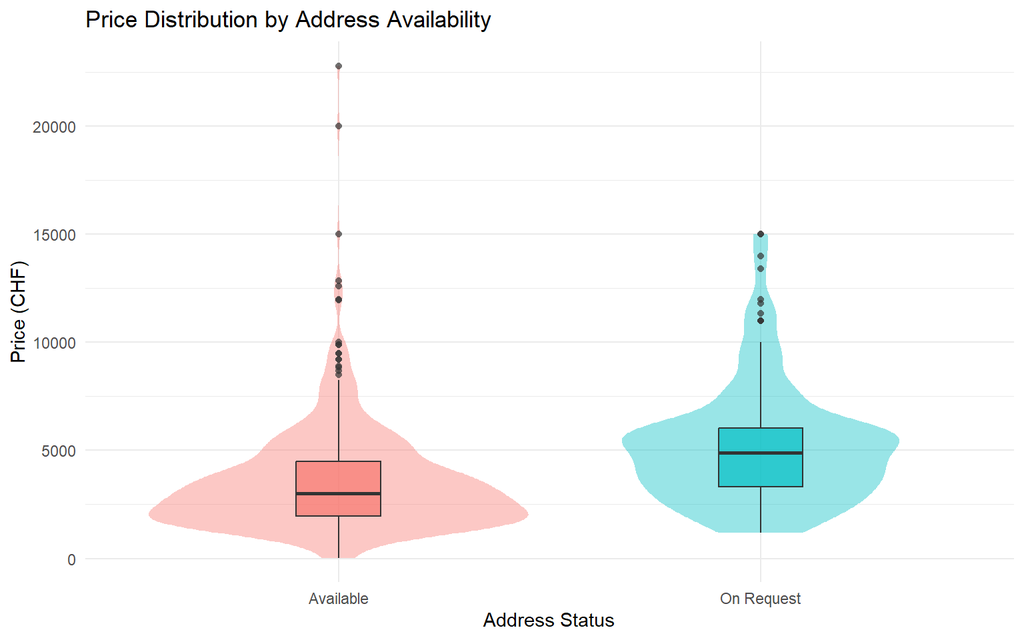

```r
ggplot(rental_clean, aes(x = address_status, y = price_chf, fill = address_status)) +
  geom_violin(alpha = 0.4, color = NA) +
  geom_boxplot(width = 0.2, outlier.shape = 16, outlier.size = 1.5, alpha = 0.7) +
  labs(
    title = "Price Distribution by Address Availability",
    x = "Address Status",
    y = "Price (CHF)",
    fill = "Address Status"
  ) +
  theme_minimal() +
  theme(legend.position = "none")
```

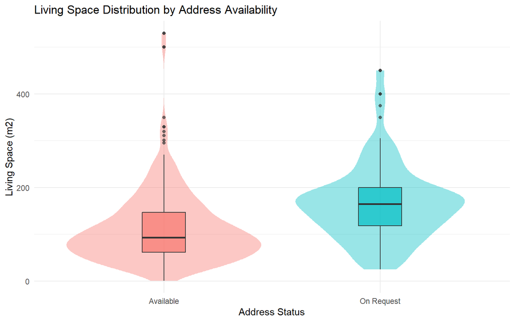

```r
ggplot(rental_clean, aes(x = address_status, y = living_space_m2, fill = address_status)) +
  geom_violin(alpha = 0.4, color = NA) +
  geom_boxplot(width = 0.2, outlier.shape = 16, outlier.size = 1.5, alpha = 0.7) +
  labs(
    title = "Living Space Distribution by Address Availability",
    x = "Address Status",
    y = "Living Space (m2)",
    fill = "Address Status"
  ) +
  theme_minimal() +
  theme(legend.position = "none")
```

My comments & interpretation Price: Properties listed as “On Request” tend to be noticeably more expensive on average than standard “Available” listings.

Living Space: Listings with addresses on demand generally feature larger living space.

## Part 6: Statistical Analysis of Price per Square Meter by Address Status

In this section, we summarize and statistically compare the price per square meter ($\text{CHF/m}^2$) between properties with publicly listed addresses (“Available”) and those listed as “On Request”.

### Step 1: Summary Statistics Table

We calculate the group size, median, mean, standard deviation, minimum, and maximum of `price_per_m2` for both address availability categories.

```r
summary_stats <- rental_clean %>%
  filter(!is.na(price_per_m2) & !is.infinite(price_per_m2)) %>%
  group_by(address_status) %>%
  summarise(
    Group_Size = n(),
    Median     = median(price_per_m2, na.rm = TRUE),
    Average    = mean(price_per_m2, na.rm = TRUE),
    Std_Dev    = sd(price_per_m2, na.rm = TRUE),
    Min        = min(price_per_m2, na.rm = TRUE),
    Max        = max(price_per_m2, na.rm = TRUE)
  )

knitr::kable(summary_stats, digits = 2, caption = "Summary Statistics of Price per m² (CHF) by Address Status")
```

Summary Statistics of Price per m² (CHF) by Address Status

| address_status | Group_Size | Median | Average | Std_Dev | Min | Max |
| --- | --- | --- | --- | --- | --- | --- |
| Available | 374 | 33.20 | 40.15 | 111.49 | 8.3 | 2180.00 |
| On Request | 132 | 33.07 | 33.93 | 9.28 | 17.5 | 71.43 |

### Step 2: Initial Observations & Data Adjustments

Data Inspection & Adjustments Before Testing: Missing / Infinite Values: Listings missing either price or surface area result in NA or Inf (if living space is 0). These must be dropped so they don’t break the statistical functions.

```r
# Clean dataset for t-test
rental_ttest_data <- rental_clean %>%
  filter(!is.na(price_per_m2) & !is.infinite(price_per_m2))
```

### Step 3:

Hypotheses to compare the mean price per square meter between the two group There is no difference in average price per square meter . Alternative Hypothesis There is a statistically significant difference in average price per square meter between the two groups

```r
ttest_result <- t.test(price_per_m2 ~ address_status, data = rental_ttest_data)
ttest_result
```

```
##
##  Welch Two Sample t-test
##
## data:  price_per_m2 by address_status
## t = 1.0681, df = 387.36, p-value = 0.2861
## alternative hypothesis: true difference in means between group Available and group On Request is not equal to 0
## 95 percent confidence interval:
##  -5.227323 17.662334
## sample estimates:
##  mean in group Available mean in group On Request
##                 40.15247                 33.93496
```

## Part 7: Statistical Analysis of Total Price by Address Status

In this section, we repeat the analysis conducted in Part 6 using total listing price (`price` in CHF) instead of unit price per square meter (`price_per_m2`).

### Step 1: Summary Statistics Table for Total Price

I calculate summary statistics for `price` grouped by address availability.

```r
summary_stats_price <- rental_clean %>%
  # Ensure price is converted to numeric (strips "CHF", "Price on request", commas, etc.)
  mutate(price_num = suppressWarnings(readr::parse_number(as.character(price)))) %>%
  # Filter out missing and infinite values
  filter(!is.na(price_num) & !is.infinite(price_num)) %>%
  group_by(address_status) %>%
  summarise(
    Group_Size = n(),
    Median     = median(price_num, na.rm = TRUE),
    Average    = mean(price_num, na.rm = TRUE),
    Std_Dev    = sd(price_num, na.rm = TRUE),
    Min        = min(price_num, na.rm = TRUE),
    Max        = max(price_num, na.rm = TRUE)
  )

knitr::kable(summary_stats_price, digits = 2, caption = "Summary Statistics of Total Rental Price (CHF) by Address Status")
```

Summary Statistics of Total Rental Price (CHF) by Address Status

| address_status | Group_Size | Median | Average | Std_Dev | Min | Max |
| --- | --- | --- | --- | --- | --- | --- |
| Available | 434 | 3000 | 3602.47 | 2499.16 | 30 | 22800 |
| On Request | 163 | 4900 | 5200.30 | 2749.58 | 1180 | 15000 |

### Step 2: Data Cleaning Chunk

filter out missing (`NA`) and infinite values

```
rental_ttest_price_data <- rental_clean %>%
  mutate(price_num = suppressWarnings(readr::parse_number(as.character(price)))) %>%
  filter(!is.na(price_num) & !is.infinite(price_num))
```

- Null Hypothesis ($H_0$): $\mu_{\text{On Request}} = \mu_{\text{Available}}$
- Alternative Hypothesis ($H_1$): $\mu_{\text{On Request}} \neq \mu_{\text{Available}}$

#### 2. Real Estate Interpretation

- Target Market Segment: Landlords and real estate agencies tend to hide property addresses “On Request” luxury rental units to protect privacy and maintain price negotiation discret.

```r
  library(tidygeocoder)
  library(leaflet)
  library(dplyr)


# 1. Select a subset of 30 properties with valid addresses
map_sample <- rental_clean %>%
  filter(!is.na(address) & address != "" & address_status == "Available") %>%
  slice_head(n = 30) %>%
  mutate(address_full = paste0(address, ", Switzerland"))

# 2. Geocode addresses using OpenStreetMap (osm method)
geocoded_sample <- map_sample %>%
  geocode(
    address = address_full,
    method  = "osm",
    lat     = latitude,
    long    = longitude
  ) %>%
  filter(!is.na(latitude) & !is.na(longitude))
```

```
## Passing 28 addresses to the Nominatim single address geocoder
```

```
## Query completed in: 28.4 seconds
```

```r
# 3. Create interactive Leaflet Map
map_widget <- leaflet(geocoded_sample) %>%
  addTiles() %>%
  addMarkers(
    lng = ~longitude,
    lat = ~latitude,
    popup = ~paste0(
      "<b>Address:</b> ", address, "<br>",
      "<b>Price:</b> ", price, " CHF<br>",
      "<b>Living Space:</b> ", living_space, " m²"
    )
  )

# Print the widget
map_widget
```

[interactive chart not shown]